# Measuring memory latency

The purpose of this notebook is to measure memory latency in EC2 instances of varying cache sizes (t2.small vs. t3a.small).

```python
from IPython.display import HTML

button  = HTML('''<script>
code_show=true;
function code_toggle() {
 if (code_show){
 $('div.input').hide();
 } else {
 $('div.input').show();
 }
 code_show = !code_show
}
$( document ).ready(code_toggle);
</script>
<form action="javascript:code_toggle()"><input type="submit" value="Click here to toggle on/off the raw code."></form>''')
```

### setting parameters

```python
n=100 # size of single block (1MB)
m_list=[1,10,100,1000,10000] # size of file in blocks
k=100000;  # number of repeats
L=len(m_list)
print('n=%d, k=%d, m_list='%(n,k),m_list)
button
```

```
n=100, k=100000, m_list= [1, 10, 100, 1000, 10000]
```

```python
log_root='./logs'
if not isdir(log_root): mkdir(log_root)
TimeStamp=str(int(time.time()))
log_dir=log_root+'/'+TimeStamp
mkdir(log_dir)
%cd $log_dir
stat=open('stats.txt','w')

def tee(line):
    print(line)
    stat.write(line+'\n')

_mean=zeros([2,L])   #0: using disk, 1: using memory
_std=zeros([2,L])
Tmem=[]
TFile=[]
button
```

```
/home/ubuntu/workspace/Public-DSC291/notebooks/Section1-Basics/0.MemoryLatency/logs/1587426812
```

# Method of trials

```python
import numpy as np
from numpy.random import rand
import time

def measureRandomAccessMemBlocks(sz,k=1000,batch=100):
    """Measure the distribution of random accesses in computer memory.

    :param sz: size of memory block.
    :param k: number of times that the experiment is repeated.
    :param batch: The number of locations poked in a single experiment (multiple pokes performed using numpy, rather than python loop)
    :returns: (_mean,std,T):
              _mean = the mean of T
              _std = the std of T
              T = a list the contains the times of all k experiments
    :rtype: tuple

    """
    # Prepare buffer.
    A=np.zeros(sz,dtype=np.int8)

    # Read and write k*batch times from/to buffer.
    sum=0; sum2=0
    T=np.zeros(k)
    for i in range(k):
        if (i%100==0): print('\r',i, end=' ')
        loc=np.int32(rand(batch)*sz)
        t=time.time()
        x=A[loc]
        A[loc]=loc
        d=(time.time()-t)/batch
        T[i]=d
        sum += d
        sum2 += d*d
    _mean=sum/k; var=(sum2/k)-_mean**2; _std=np.sqrt(var)
    return (_mean,_std,T)
button
```

### Characterize random access to storage

We print the following values that were stored in a pandas dataframe:

```python
means_stds = np.array(df_means)
print(means_stds)
```

```
[3.94495352e-08 2.34703279e-08 4.62968721e-08 4.40403518e-08
 4.83386948e-08 5.36017701e-08 8.04886682e-08 2.25649828e-07
 9.13546003e-08 2.56614072e-07 9.90579068e-08 2.74413196e-07
 1.11012554e-07 3.16084737e-07 1.19584627e-07 3.22314975e-07
 1.27087461e-07 3.34632574e-07]
```

## Visualize a single trial run

[figure not shown]

```python
pp = PdfPages('MemoryBlockFigure.pdf')
figure(figsize=(6,4))

Colors=['red', 'orange', 'blue', 'orchid', 'green', 'aqua', 'fuchsia', 'coral', 'plum', 'olive']  # The colors for the plot
LineStyles=['-']

fig = matplotlib.pyplot.gcf()
fig.set_size_inches(18.5,10.5)

for m_i in range(len(m_list)):
    Color=Colors[m_i % len(Colors)]
    PlotTime(TMem[m_i],_mean[m_i],_std[m_i],\
             Color=Color,LS='-',Legend=m_legend[m_i],\
             m_i=m_i)

grid()
legend(fontsize=18)
title('Single trial run latency for varying block sizes', fontsize=20)
xlabel('delay (sec)',fontsize=18)
ylabel('1-CDF',fontsize=18)
tick_params(axis='both', which='major', labelsize=16)
tick_params(axis='both', which='minor', labelsize=12)
pp.savefig()
pp.close()
```

## Visualize the averaged means, standard deviations over an hour:

[figure not shown]

```python
import matplotlib.pyplot as plt
import numpy as np


means = []
stds = []
for i in range(0, int(len(means_stds)/2)):
    means.append(means_stds[2*i])
    stds.append(means_stds[2*i+1])


x = m_list
y = means
e = stds

plt.errorbar(x, y, e, linestyle='None', marker='^')

# Add title and axis names
plt.title('      Averaged Latency Means and Standard Deviation')
plt.xlabel('Block Size')
plt.ylabel('Latency')

plt.show()
```

# Comparison between t3a.small and t2.small instances

| Instance Type | Processor | L1d cache | L2 cache | L3 cache |
| --- | --- | --- | --- | --- |
| t2.small | Intel Xeon E5-2676 | 12 x 32 KB | 12 x 256 KB | 30 MB |
| t3a.small | AMD EPYC 7571 | 32 x 32 KB | 32 x 512 KB | 8 x 8 MB |

The effecticve cahce size of t2.small instance is ~33MB.

The effecticve cahce size of t3a.small instance is ~80MB

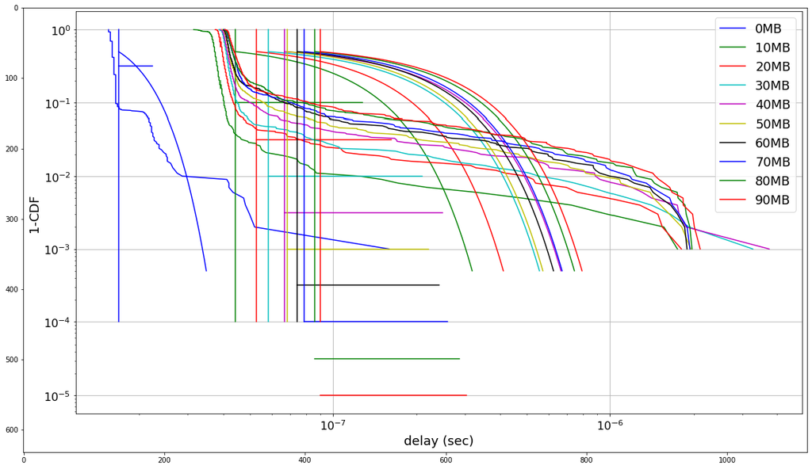

```python
image = mpimg.imread("fig/t3a.png")
plt.figure(figsize=(20,13))
plt.imshow(image)
plt.show()
```

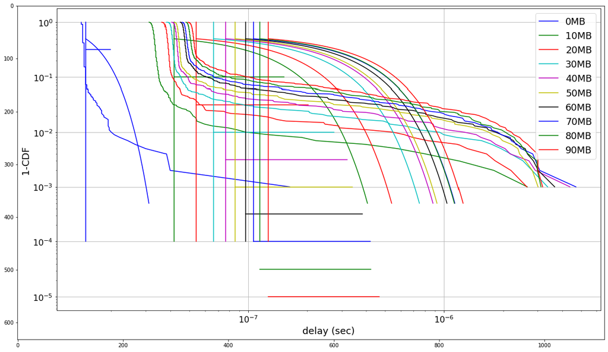

```python
image = mpimg.imread("fig/t2.png")
plt.figure(figsize=(20,13))
plt.imshow(image)
plt.show()
```

# Statistical tests comparing t3.small and t2.small instances

- The p-test for the case of 10, 20, 30, 40, 50MB is greater than 0.05 and for the rest of the block sizes we can reject the Null hypothesis in the favor of out Alternative hypothesis.
- Our hypotheis is correct because when the block size becomes considerably larger the L3 cache size of the t2.small instance but is still smaller than the L3 cache size of t3a.small, than the t3a.small performs better than t2.small.

```python
for idx in range(0, 10):
    t3 = t3asmall_df.loc[idx, 'memory_latencies']
    t2 = t2small_df.loc[idx, 'memory_latencies']
    print('t-test for {}0MB'.format(idx))
    print(ttest_ind(t3, t2))
```

```
t-test for 00MB
Ttest_indResult(statistic=8.715188670543206, pvalue=5.979098166289906e-18)
t-test for 10MB
Ttest_indResult(statistic=0.6203383052222069, pvalue=0.5351058276619569)
t-test for 20MB
Ttest_indResult(statistic=-0.20819176098143696, pvalue=0.8351004609545761)
t-test for 30MB
Ttest_indResult(statistic=-1.0002208838885052, pvalue=0.3173247428554567)
t-test for 40MB
Ttest_indResult(statistic=-1.0173865814162821, pvalue=0.30909274067238474)
t-test for 50MB
Ttest_indResult(statistic=-1.8625586578953108, pvalue=0.06267105769189524)
t-test for 60MB
Ttest_indResult(statistic=-2.1669210167912007, pvalue=0.030358703917979624)
t-test for 70MB
Ttest_indResult(statistic=-2.4062578203510343, pvalue=0.01620717247610227)
t-test for 80MB
Ttest_indResult(statistic=-2.422890259943754, pvalue=0.015485945923862609)
t-test for 90MB
Ttest_indResult(statistic=-2.8997619130330112, pvalue=0.0037752431570886626)
```

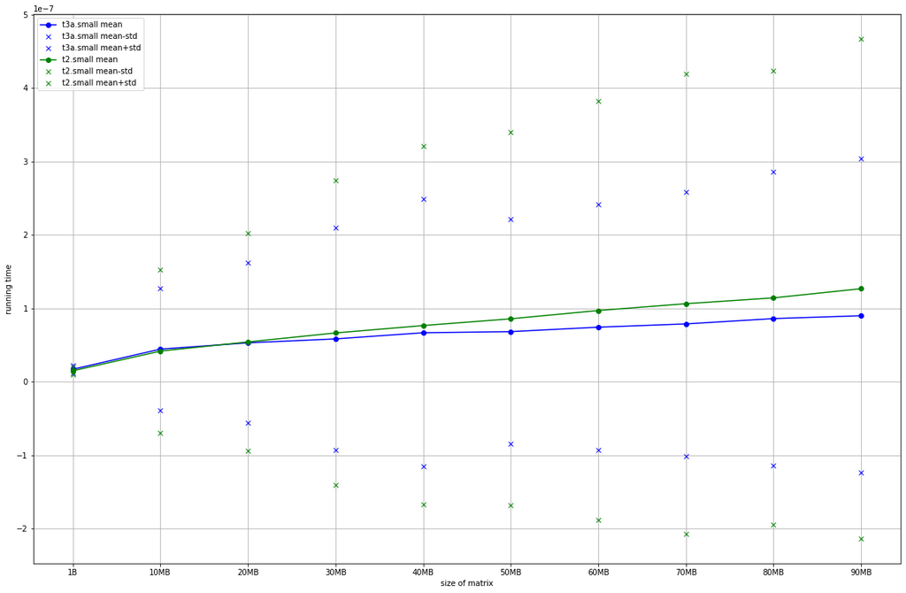

```python
m_legend=['1B','10MB', '20MB', '30MB', '40MB', '50MB', '60MB', '70MB', '80MB', '90MB']
plt.figure(figsize=(20,13))
plt.plot(m_legend, t3asmall_df['memory__mean'],'o-b',label='t3a.small mean')
plt.plot(m_legend,t3asmall_df['memory__mean']-t3asmall_df['memory__std'],'xb',label='t3a.small mean-std')
plt.plot(m_legend,t3asmall_df['memory__mean']+t3asmall_df['memory__std'],'xb',label='t3a.small mean+std')
plt.plot(m_legend, t2small_df['memory__mean'],'o-g',label='t2.small mean')
plt.plot(m_legend,t2small_df['memory__mean']-t2small_df['memory__std'],'xg',label='t2.small mean-std')
plt.plot(m_legend,t2small_df['memory__mean']+t2small_df['memory__std'],'xg',label='t2.small mean+std')
plt.xlabel('size of matrix')
plt.ylabel('running time')
plt.legend()
plt.grid()
```

# Acknowledgments

Many components producing the results in this notebook were sourced from the course material for DSC 291 at the University of California San Diego under the instruction of Yoav Freund. Source material may be freely installed using

> $ git clone https://github.com/yoavfreund/Public-DSC291